# Prepare AWS SoilStations dataset

Maite

2 12 2021

### Read Soil Station data

Files were read and non-empty columns retained. A column name from the first three lines of the excel files was created. Finally, the so created column names were matched to the pattern for the following variables of interest:

ID, Year, Hour, Date Air Temp (°C, 1.6m) Solar Radiation (W/m²), 3m Wind Speed (m/s), 3m Wind Direction (azimuth), 3m

Soil Temp (°C) Surface under white rock Soil Temp (°C) Surface under black rock

Soil RH (%) 5cm Soil RH (%) 15cm

MRC Soil Temp °C 0 in MRC Soil Temp °C 3 in 7,6cm

Soil 2cm: ER unitless Real dielectric constant EI unitless Imaginary dielectric constant Temp °C Temperature ER_COR unitless Temperature corrected ER EI_COR unitless Temperature corrected EI WATER wfv Soil moisture SALINITY g NaCl/L Soil salinity SOIL_COND S/m Soil conductivity SOIL_COND_COR S/m Temp corrected soil conductivity WATER_CON_COR S/m Temp corrected conductivity of the water in the soil

```r
sdirs <- list.dirs(here("../calib_valid/AWS/SoilStations/"))[-1]

# PATTERNS FOR SUBSETTING THE DATASETS
# BULL PASS
pat_BP <- c("ID","YEAR_NA_NA", "HOUR_NA_NA", "DATE_NA_NA",
         "Air_Temp_deg_C", "Solar_Radiation_W/m2",
         "Wind_Speed_m/s", "Wind_Direction_deg_True_N",
         "Soil_Temp_2_cm_White_deg_C", "Soil_Temp_2_cm_Black_deg_C",
         "MRC_0_cm_deg_C", "MRC_7.5_cm_deg_C", "SOIL_RH_%", "SOIL_RH_%",
         "ER_2_cm,_1_NA", "EI_2_cm,_1_NA","TEMP_2_cm,_1_deg_C",
         "ER_COR_2_cm,_1_NA","EI_COR_2_cm,_1_NA","WATER_2_cm,_1_wfv" ,
         "SALINITY_2_cm,_1_g_NaCl/L",   "SOIL_COND_2_cm,_1_S/m","SOIL_COND_COR_2_cm,_1_S/m" ,
         "WATER_CON_COR_2_cm,_1_S/m")

# BULL PASS EAST
# don't exist: "Soil_Temp_2_cm_White_deg_C", "Soil_Temp_2_cm_Black_deg_C",
# MRC_5.5_cm_deg_C instead of 7.5cm
# instead of "SOIL_RH_%" there is "Soil_RH_2cm_%"
# Bull Pass East from 2019 is mostly empty
pat_BPE <- c("ID","YEAR_NA_NA", "HOUR_NA_NA", "DATE_NA_NA",
         "Air_Temp_deg_C", "Solar_Radiation_W/m2","Relative_Humidity_%",
         "Wind_Speed_m/s", "Wind_Direction_deg_True_N",
         "MRC_0_cm_deg_C", "MRC_5_cm_deg_C",
         "Soil_RH_2_cm_%","Soil_Temp_2_cm_deg_C",
         "ER_2_cm,_1_NA", "EI_2_cm,_1_NA","TEMP_2_cm,_1_deg_C",
         "ER_COR_2_cm,_1_NA","EI_COR_2_cm,_1_NA","WATER_2_cm,_1_wfv" ,
         "SALINITY_2_cm,_1_g_NaCl/L",   "SOIL_COND_2_cm,_1_S/m","SOIL_COND_COR_2_cm,_1_S/m" ,
         "WATER_CON_COR_2_cm,_1_S/m")

# DON JUAN POND
# don't exist: "Soil_Temp_2_cm_White_deg_C", "Soil_Temp_2_cm_Black_deg_C",
# MRC_5_cm_deg_C instead of 7.5cm
# instead of "SOIL_RH_%", there's "Soil_RH_2_cm_%"
# 2019: data missing
pat_DJP <- c("ID","YEAR_NA_NA", "HOUR_NA_NA", "DATE_NA_NA",
         "Air_Temp_deg_C", "Solar_Radiation_W/m2",
         "Wind_Speed_m/s", "Wind_Direction_deg_True_N",
         "MRC_0_cm_deg_C", "MRC_5_cm_deg_C", "Soil_RH_2_cm_%",
         "ER_2_cm,_1_NA", "EI_2_cm,_1_NA","TEMP_2_cm,_1_deg_C",
         "ER_COR_2_cm,_1_NA","EI_COR_2_cm,_1_NA","WATER_2_cm,_1_wfv" ,
         "SALINITY_2_cm,_1_g_NaCl/L",   "SOIL_COND_2_cm,_1_S/m","SOIL_COND_COR_2_cm,_1_S/m" ,
         "WATER_CON_COR_2_cm,_1_S/m")
# GRANITE HARBOUR
# don't exist: "Soil_Temp_2_cm_White_deg_C", "Soil_Temp_2_cm_Black_deg_C",
# Air_Temp,_1_deg_C
# MRC MRC_5.5_cm_deg_C instead of 7.5 or 5
# No soil RH
# ER,, EI, etc 2.5cm instead of 2cm
pat_GH <- c("ID","YEAR_NA_NA", "HOUR_NA_NA", "DATE_NA_NA",
         "Air_Temp,_1_deg_C", "Solar_Radiation_w/m2",
         "Wind_Speed_m/s", "Wind_Direction_deg_True_N",
         "MRC_0_cm_deg_C", "MRC_5.5_cm_deg_C",
         "ER_2.5_cm_NA","EI_2.5_cm_NA","TEMP_2.5_cm_deg_C","ER_COR_2.5_cm_NA",
         "EI_COR_2.5_cm_NA","WATER_2.5_cm_wfv","SALINITY_2.5_cm_g_NaCl/L",
         "SOIL_COND_2.5_cm_S/m","SOIL_COND_COR_2.5_cm_S/m","WATER_CON_COR_2.5_cm_S/m" )

# MARBLE POINT
# don't exist: "Soil_Temp_2_cm_White_deg_C", "Soil_Temp_2_cm_Black_deg_C",
# "SOIL_RH_%" doesn't exist, instead:
pat_MP <-  c("ID","YEAR_NA_NA", "HOUR_NA_NA", "DATE_NA_NA",
         "Air_Temp_deg_C", "Solar_Radiation_W/m2",
         "Wind_Speed_m/s", "Wind_Direction_deg_True_N",
         "MRC_0_cm_deg_C", "MRC_7.5_cm_deg_C",
         "ER_2_cm,_1_NA", "EI_2_cm,_1_NA","TEMP_2_cm,_1_deg_C",
         "ER_COR_2_cm,_1_NA","EI_COR_2_cm,_1_NA","WATER_2_cm,_1_wfv" ,
         "SALINITY_2_cm,_1_g_NaCl/L",   "SOIL_COND_2_cm,_1_S/m","SOIL_COND_COR_2_cm,_1_S/m" ,
         "WATER_CON_COR_2_cm,_1_S/m")

# MOUNT FLEMMING
# don't exist: "Soil_Temp_2_cm_White_deg_C", "Soil_Temp_2_cm_Black_deg_C"
# no MRC, instead  "Soil_Temp_Poly2cm_deg_C"     "Soil_Temp_Poly7.5cm_deg_C"
# no SOIL_RH_%
pat_MtF <- c("ID","YEAR_NA_NA", "HOUR_NA_NA", "DATE_NA_NA",
         "Air_Temp_deg_C", "Solar_Radiation_W/m2",
         "Wind_Speed_m/s", "Wind_Direction_deg_True_N",
          "Soil_Temp_Poly2cm_deg_C","Soil_Temp_Poly7.5cm_deg_C",
         "ER_7.5_cm,_1_NA","EI_7.5_cm,_1_NA","TEMP_7.5_cm,_1_deg_C",
         "ER_COR_7.5_cm,_1_NA","EI_COR_7.5_cm,_1_NA", "WATER_7.5_cm,_1_wfv",
         "SALINITY_7.5_cm,_1_g_NaCl/L", "SOIL_COND_7.5_cm,_1_S/m",
         "SOIL_COND_COR_7.5_cm,_1_S/m" ,"WATER_CON_COR_7.5_cm,_1_S/m")

# don't exist: "Soil_Temp_2_cm_White_deg_C", "Soil_Temp_2_cm_Black_deg_C"
# no soil RH
#
pat_VV <- c("ID","YEAR_NA_NA", "HOUR_NA_NA", "DATE_NA_NA",
         "Air_Temp_deg_C", "Solar_Radiation_w/m2",
         "Wind_Speed_m/s", "Wind_Direction_deg_True_N",
         "MRC_0_cm_deg_C", "MRC_7.5_cm_deg_C",
         "ER_3_cm,_2_NA","EI_3_cm,_2_NA","TEMP_3_cm,_2_deg_C","ER_COR_3_cm,_2_NA",
         "EI_COR_3_cm,_2_NA","WATER_3_cm,_2_wfv","SALINITY_3_cm,_2_g_NaCl/L",
         "SOIL_COND_3_cm,_2_S/m","SOIL_COND_COR_3_cm,_2_S/m" , "WATER_CON_COR_3_cm,_2_S/m")


pat_list <- list(pat_BP, pat_BPE, pat_DJP, pat_GH, pat_MP, pat_MtF, pat_VV)
shortID <- list("BP", "BPE", "DJP", "GH", "MP", "MtF", "VV")
```

### Just for testing the patterns

```r
checktabs <- lapply(seq(sdirs), function(d){ # for all different stations
  print(paste0("d= ",d))
  f <- list.files(sdirs[d], full.names=T,pattern=".xls")
  stat_year <- lapply(seq(length(f)), function(y){ # for all years available for this station
  # loop through all of the files
      print(y)
      names_df <- read_excel(f[y],
           col_names = F)
      # get rid of empty columns
      any(is.na(names_df[5,]))

      isnadf <- is.na(names_df[200:216,])
      full_cols <- which(colSums(isnadf)!=16)

      pastenams <- apply(names_df[1:3,], 2, paste , collapse = "_" )
      pastenams <- gsub(" ", "_", pastenams)
      pastenams <- pastenams[full_cols]

      tab <- read_excel(f[y], .name_repair = "unique",
                 skip=3)

      isnatabdf <- is.na(tab[200:216,])
      full_cols_tab <- which(colSums(isnatabdf)!=16)
      tab <- tab[,full_cols_tab]
      ncol(tab)
      length(pastenams)

      names(tab) <- pastenams

      names(tab)[1] <- "ID"
      tab$ID <- shortID[[d]]

      return(tab[1:10,])
  })
})

names(checktabs) <- basename(sdirs)[1:length(checktabs)]
# saveRDS(checktabs, here("../calib_valid/AWS/SoilStations/checktabs.rds"))
```

Finding out what’s going on:

```r
# which variables in pat are in checktab names?
check_varsel <- lapply(seq(checktabs), function(d){ # for all different stations
  sapply(seq(checktabs[[d]]), function(y){ # for all years available for this station
    sel <- which(names(checktabs[[d]][[y]]) %in% pat_list[[d]])
    length(sel)
    return(length(sel))
  })
})

names(check_varsel) <- basename(sdirs)[1:length(checktabs)]
check_varsel

# different naming for different stations?

'%notin%' <- Negate('%in%')

# which columns could not be matched?
pat_not_matched <- lapply(seq(checktabs), function(d){ # for all different stations
  s <- lapply(seq(checktabs[[d]]), function(y){ # for all years available for this station
    not_matched <- which(pat_list[[d]] %notin% names(checktabs[[d]][[y]]))
    return(pat[not_matched])
  })
  names(s) <- station_year[[d]]
  return(s)
})

names(pat_not_matched) <- basename(sdirs)[1:length(checktabs)]


# look into names per station
dy_names <- lapply(seq(checktabs), function(d){ # for all different stations
  s <- sapply(seq(checktabs[[d]]), function(y){ # for all years available for this station
    names(checktabs[[d]][[y]])
  })
  names(s) <- station_year[[d]]
  return(s)
})
names(dy_names) <- basename(sdirs)[1:length(checktabs)]
```

```r
# BULL PASS
check_varsel$BullPass # to see whether there are differences over the years
pat_not_matched$BullPass # all good
# dy_names$BullPass$'2012' # all names in respective climate station

# BULL PASS EAST
check_varsel$BullPassEast # to see whether there are differences over the years
pat_not_matched$BullPassEast # which in pattern could not be matched
# SOLVE: WHY IS MRC_0_cm_deg_C NOT MATCHED ALTHOUGH ITS IN PATTERN AND FILENAMES?????
dy_names$BullPassEast$'2012' # all names in respective climate station

# DON JUAN POND
check_varsel$DonJuanPond # to see whether there are differences over the years
pat_not_matched$DonJuanPond # which in pattern could not be matched
# dy_names$DonJuanPond$'2012' # all names in respective climate station
# adapt pattern to match the station using the data labels word-document

# GRANITE HARBOUR
check_varsel$GraniteHarbour # to see whether there are differences over the years
pat_not_matched$GraniteHarbour # which in pattern could not be matched
# all good
# dy_names$GraniteHarbour$'2012' # all names in respective climate station

# MARBLE POINT
check_varsel$MarblePoint # to see whether there are differences over the years
pat_not_matched$MarblePoint # which in pattern could not be matched
# dy_names$MarblePoint$'2012' # all names in respective climate station

# MtFlemming
check_varsel$MtFlemming # to see whether there are differences over the years
pat_not_matched$MtFlemming # which in pattern could not be matched
# dy_names$MtFlemming$'2012' # all names in respective climate station

# vICTORIA VALLEY
check_varsel$VictoriaValley # to see whether there are differences over the years
pat_not_matched$VictoriaValley # which in pattern could not be matched
# dy_names$VictoriaValley$'2012' # all names in respective climate station
```

### Now reading in the actual datasets and saving as RMD

```r
tabs <- lapply(seq(sdirs), function(d){ # for all different stations
  print(paste0("d= ",d))
  f <- list.files(sdirs[d], full.names=T,pattern=".xls")
  stat_year <- lapply(seq(length(f)), function(y){ # for all years available for this station
  # loop through all of the files
      print(y)
      names_df <- read_excel(f[y],
           col_names = F)
      # get rid of empty columns
      any(is.na(names_df[5,]))

      isnadf <- is.na(names_df[200:216,])
      full_cols <- which(colSums(isnadf)!=16)

      pastenams <- apply(names_df[1:3,], 2, paste , collapse = "_" )
      pastenams <- gsub(" ", "_", pastenams)
      pastenams <- pastenams[full_cols]

      tab <- read_excel(f[y], .name_repair = "unique",
                 skip=3)

      isnatabdf <- is.na(tab[200:216,])
      full_cols_tab <- which(colSums(isnatabdf)!=16)
      tab <- tab[,full_cols_tab]
      ncol(tab)
      length(pastenams)

      names(tab) <- pastenams

      names(tab)[1] <- "ID"
      tab$ID <- shortID[[d]]

      return(tab)
  })
})


names(tabs) <- basename(sdirs)
# saveRDS(tabs, here("../calib_valid/AWS/SoilStations/all_SoilStation_data.rds"))
```

Subsetting by the pattern

```r
# get year corresponding to y per station
station_year <- lapply(seq(tabs), function(d){ # for all different stations
  sapply(seq(tabs[[d]]), function(y){ # for all years available for this station
    tabs[[d]][[y]]$YEAR_NA_NA[1]
  })
})

# subset by name
tabs_varsel <- lapply(seq(tabs), function(d){ # for all different stations
  s <- lapply(seq(tabs[[d]]), function(y){ # for all years available for this station
    sel <- which(names(tabs[[d]][[y]]) %in% pat_list[[d]])
    ts <- tabs[[d]][[y]][,sel]
    return(ts)
  })
  names(s) <- station_year[[d]]
  return(s)
})

names(tabs_varsel) <- basename(sdirs)[1:length(tabs_varsel)]
```

### check, whether all are there

```r
'%notin%' <- Negate('%in%')
# which columns could not be matched?
pat_not_matched_tabs <- lapply(seq(tabs_varsel), function(d){ # for all different stations
  s <- lapply(seq(tabs_varsel[[d]]), function(y){ # for all years available for this station
    not_matched <- which(names(tabs_varsel[[d]][[y]])  %notin% pat_list[[d]])
    return(pat_list[[d]][not_matched])
  })
  names(s) <- station_year[[d]]
  return(s)
})

names(pat_not_matched_tabs) <- basename(sdirs)[1:length(tabs_varsel)]
```

All good except for Bull Pass East not having MRC_0_cm_deg_C (don’t understand why) and a lot of missing data in 2019, also Don Juan Pond is missing data in 2019.

Writing to a RDS file

```r
# saveRDS(tabs_varsel, here("../calib_valid/AWS/SoilStations/tabs_varsel.rds"))
```

### Match

```r
library(dplyr)

cols_per_station <- lapply(seq(tabs_varsel), function(d){
  sapply(seq(tabs_varsel[[d]]), function(y){
  ncol(tabs_varsel[[d]][[y]])
})
})

names(cols_per_station) <- shortID

BP_one_missing <- do.call("rbind", tabs_varsel$BullPass[c(1,3:length(tabs_varsel$BullPass))])
BPE_no_19 <- do.call("rbind", tabs_varsel$BullPassEast[1:7])
DJP_no_19 <- do.call("rbind", tabs_varsel$DonJuanPond[1:8])

BP_allyears <- bind_rows(BP_one_missing, tabs_varsel$BullPassEast[[2]])
BPE_allyears <- bind_rows(BPE_no_19, tabs_varsel$BullPassEast[[8]])
DJP_allyears <- bind_rows(DJP_no_19, tabs_varsel$DonJuanPond[[9]])
GH_allyears <- do.call("rbind", tabs_varsel$GraniteHarbour)
MP_allyears <- do.call("rbind", tabs_varsel$MarblePoint)
MtF_allyears <- do.call("rbind", tabs_varsel$MtFlemming)
VV_allyears <- do.call("rbind", tabs_varsel$VictoriaValley)


stations <- list(BP_allyears, BPE_allyears, DJP_allyears, GH_allyears,
     MP_allyears, MtF_allyears, VV_allyears)

names(stations) <- shortID
```

1. Keep BP, BPE and DJP together for relating soil RH to SMC
2. One full version: kill Soil_Temp_2_cm_White_deg_C and Soil_Temp_2_cm_Black_deg_C as well as both SOIL_RH_% in BP. Then join all together and rename as in excel file:

```r
stations <- readRDS(here("../calib_valid/AWS/SoilStations/stations_allyears.rds"))
nam <- lapply(seq(stations), function(d){
  names(stations[[d]])
})
allstat <- do.call("rbind", stations)

# saveRDS(allstat, here("../calib_valid/AWS/SoilStations/all_AWSS_all_years.rds"))
```

# The head of the final result

```r
saws <- readRDS(here("../calib_valid/AWS/SoilStations/all_AWSS_all_years.rds"))
knitr::kable(head(saws))
```

| ID | YEAR | HOUR | DATE | AirT | SolarRad | WindDir | WindSpeed | SoilT0_2 | SoilT5_7 | ER | EI | Temp | ER_COR | EI_COR | SMC | SAL | COND | COND_COR | WAT_COND_COR |
| --- | --- | --- | --- | --- | --- | --- | --- | --- | --- | --- | --- | --- | --- | --- | --- | --- | --- | --- | --- |
| BP | 2008 | 100 | 2008-01-01 | -3.837 | 134.5 | 99.4 | 4.91700 | 0.050 | 1.023 | 3.58 | 0.50 | 0.51 | 3.47 | 0.77 | 0.015 | 0.0855 | 0.0014 | 0.0021 | 0.8899 |
| BP | 2008 | 200 | 2008-01-01 | -3.625 | 133.4 | 99.5 | 5.78418 | 0.798 | 0.961 | 3.48 | 0.54 | 0.67 | 3.37 | 0.82 | 0.013 | 0.0939 | 0.0015 | 0.0023 | 1.1686 |
| BP | 2008 | 300 | 2008-01-01 | -3.687 | 97.3 | 102.8 | 6.00768 | 0.555 | 0.948 | 3.57 | 0.49 | 0.79 | 3.46 | 0.74 | 0.015 | 0.0828 | 0.0014 | 0.0021 | 0.8663 |
| BP | 2008 | 400 | 2008-01-01 | -4.146 | 71.1 | 97.3 | 5.86464 | -0.392 | 0.822 | 3.46 | 0.57 | 0.64 | 3.35 | 0.87 | 0.012 | 0.1006 | 0.0016 | 0.0024 | 1.3150 |
| BP | 2008 | 500 | 2008-01-01 | -4.095 | 80.6 | 96.5 | 5.12709 | -0.701 | 0.583 | 3.58 | 0.50 | 0.32 | 3.46 | 0.77 | 0.015 | 0.0859 | 0.0014 | 0.0021 | 0.8994 |
| BP | 2008 | 600 | 2008-01-01 | -3.793 | 94.6 | 91.2 | 4.35378 | -0.427 | 0.368 | 3.61 | 0.48 | 0.18 | 3.49 | 0.74 | 0.016 | 0.0820 | 0.0013 | 0.0021 | 0.8190 |

# observations per climate station

```r
table(saws$ID)
```

```
##
##     BP    BPE    DJP     GH     MP    MtF     VV
##  95980  52639  61180 144228 179646 144912 183536
```

# log SMC

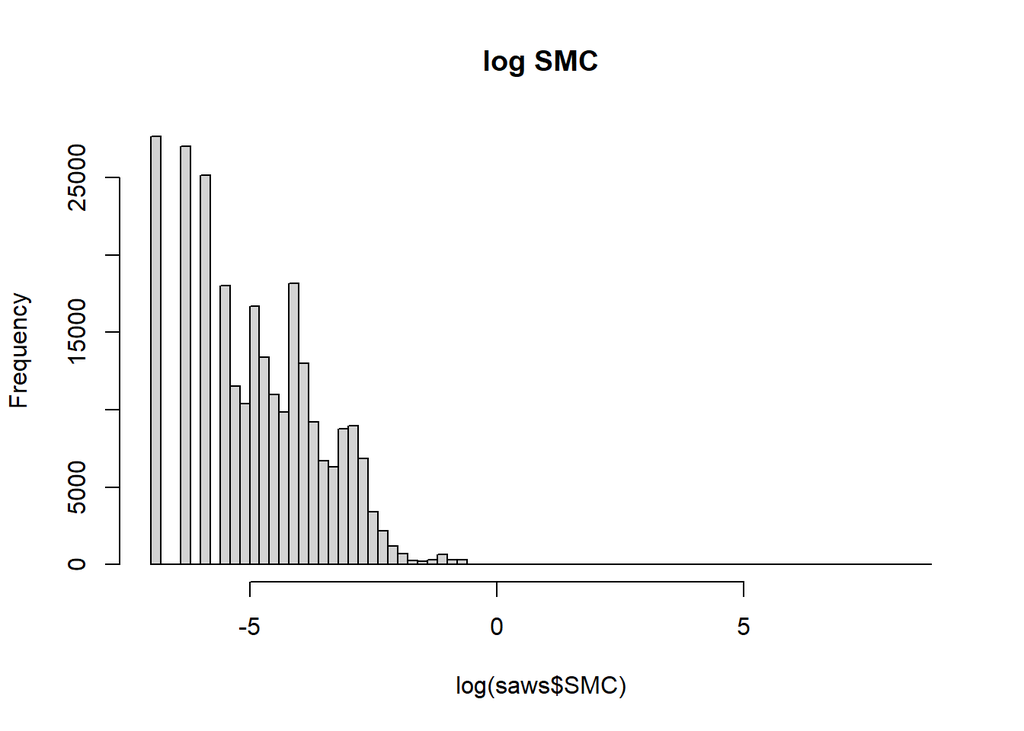

```r
hist(log(saws$SMC),
     breaks=60,
     main="log SMC")
```